# Principal Component Analysis (PCA)

Pablo E. Gutiérrez-Fonseca

8/26/2021

1. Primer paso: cargar las librerias que necesitas.

```r
library(ggplot2)
library(dplyr)
library(missMDA) # Imputate
library(ggfortify) # autoplot()
library(cluster) #pam
library(factoextra) #get_pca_var()
library(data.table) # data.table()
library(labdsv) #loadings.pca(pca)

# library(devtools)

# install_github("vqv/ggbiplot") #ggbiplot
# library(ggbiplot)
```

2. Segundo paso: cargar los datos.

```r
channel <- read.csv("data/PCA_channel_form.csv", header=TRUE)
head(channel)
```

|  | Forma | NAN_Am | NADBO | NAtemp | nit | NASatO2 | Elevacion | Ancho | Velocidad | Rocas | Canto | grava | arena | Limo |
| --- | --- | --- | --- | --- | --- | --- | --- | --- | --- | --- | --- | --- | --- | --- |
| 1 | Trapecio | 0.03 | 2.38 | 27.33 | 0.35 | 92.04 | 23 | 16 | 5 | 20 | 25 | 30 | 20 | 0 |
| 2 | Trapecio | 0.03 | 2.95 | 27.81 | NA | 100.03 | 31 | 11 | 0 | 20 | 45 | 20 | 15 | 0 |
| 3 | Trapecio | 0.03 | 3.13 | 24.27 | NA | 96.82 | 35 | 14 | 10 | 30 | 30 | 20 | 10 | 0 |
| 4 | Trapecio | 1.15 | 4.73 | 27.06 | 7.54 | 64.35 | 9 | 5 | 2 | 0 | 0 | 0 | 50 | 50 |
| 5 | Trapecio | 0.50 | 8.16 | 26.60 | NA | 110.39 | 43 | 11 | 9 | 10 | 40 | 10 | 20 | 20 |
| 6 | Trapecio | 0.53 | 8.57 | 23.82 | NA | 106.09 | 23 | 11 | 5 | 20 | 60 | 20 | 0 | 0 |

```r
tail(channel)
```

|  | Forma | NAN_Am | NADBO | NAtemp | nit | NASatO2 | Elevacion | Ancho | Velocidad | Rocas | Canto | grava | arena | Limo |
| --- | --- | --- | --- | --- | --- | --- | --- | --- | --- | --- | --- | --- | --- | --- |
| 133 | V-Shape | 0.11 | 13.47 | 21.83 | 0.00 | 102.92 | 952 | 1 | 14 | 50 | 20 | 20 | 10 | 0 |
| 134 | V-Shape | 0.03 | 12.34 | 25.95 | 0.79 | 105.50 | 422 | 2 | 13 | 30 | 40 | 20 | 10 | 0 |
| 135 | V-Shape | 0.04 | 1.90 | 26.88 | NA | 92.18 | 144 | 3 | 15 | 50 | 30 | 10 | 5 | 5 |
| 136 | V-Shape | 0.03 | NA | 26.01 | NA | 88.20 | 200 | 3 | 14 | 15 | 30 | 30 | 20 | 5 |
| 137 | V-Shape | 0.03 | NA | 24.81 | NA | 91.41 | 327 | 2 | 13 | 40 | 30 | 20 | 8 | 2 |
| 138 | V-Shape | 0.03 | NA | 25.58 | NA | 89.52 | 60 | 3 | 15 | 30 | 25 | 10 | 30 | 5 |

2.1 Vamos a examinar los datos

```r
summary(channel)
```

```
##     Forma               NAN_Am           NADBO            NAtemp
##  Length:138         Min.   :0.0200   Min.   : 1.310   Min.   :14.67
##  Class :character   1st Qu.:0.0400   1st Qu.: 1.930   1st Qu.:24.30
##  Mode  :character   Median :0.2150   Median : 3.000   Median :26.05
##                     Mean   :0.3201   Mean   : 6.164   Mean   :25.84
##                     3rd Qu.:0.5000   3rd Qu.: 8.585   3rd Qu.:27.70
##                     Max.   :1.5000   Max.   :34.900   Max.   :32.18
##                                      NA's   :35
##       nit            NASatO2         Elevacion           Ancho
##  Min.   :  0.00   Min.   : 23.43   Min.   :   3.00   Min.   : 1.000
##  1st Qu.:  0.40   1st Qu.: 86.24   1st Qu.:  25.25   1st Qu.: 2.000
##  Median :  0.92   Median : 94.59   Median :  53.00   Median : 3.000
##  Mean   : 12.00   Mean   : 91.05   Mean   : 230.89   Mean   : 3.875
##  3rd Qu.:  1.62   3rd Qu.:100.52   3rd Qu.: 269.25   3rd Qu.: 3.000
##  Max.   :324.11   Max.   :122.73   Max.   :2370.00   Max.   :16.000
##  NA's   :57                                          NA's   :2
##    Velocidad          Rocas           Canto           grava
##  Min.   : 0.000   Min.   : 0.00   Min.   : 0.00   Min.   : 0.00
##  1st Qu.: 3.000   1st Qu.: 0.00   1st Qu.: 0.00   1st Qu.: 3.75
##  Median :11.000   Median :10.00   Median :25.00   Median :20.00
##  Mean   : 9.169   Mean   :16.27   Mean   :25.46   Mean   :17.86
##  3rd Qu.:14.000   3rd Qu.:30.00   3rd Qu.:40.00   3rd Qu.:25.00
##  Max.   :16.000   Max.   :90.00   Max.   :80.00   Max.   :80.00
##  NA's   :2        NA's   :2       NA's   :2       NA's   :2
##      arena             Limo
##  Min.   :  0.00   Min.   :  0.00
##  1st Qu.: 10.00   1st Qu.:  0.00
##  Median : 15.00   Median :  7.50
##  Mean   : 19.83   Mean   : 20.51
##  3rd Qu.: 25.00   3rd Qu.: 25.00
##  Max.   :100.00   Max.   :100.00
##  NA's   :2        NA's   :2
```

2.1 Remover la(s) variable(s) que tiene(n) mucho NAs y las Etiquetas (a la funcion lo le gusta), luego las agregamos.

```r
channel_1 <- select(channel, -Forma)
summary(channel_1)
```

```
##      NAN_Am           NADBO            NAtemp           nit
##  Min.   :0.0200   Min.   : 1.310   Min.   :14.67   Min.   :  0.00
##  1st Qu.:0.0400   1st Qu.: 1.930   1st Qu.:24.30   1st Qu.:  0.40
##  Median :0.2150   Median : 3.000   Median :26.05   Median :  0.92
##  Mean   :0.3201   Mean   : 6.164   Mean   :25.84   Mean   : 12.00
##  3rd Qu.:0.5000   3rd Qu.: 8.585   3rd Qu.:27.70   3rd Qu.:  1.62
##  Max.   :1.5000   Max.   :34.900   Max.   :32.18   Max.   :324.11
##                   NA's   :35                       NA's   :57
##     NASatO2         Elevacion           Ancho          Velocidad
##  Min.   : 23.43   Min.   :   3.00   Min.   : 1.000   Min.   : 0.000
##  1st Qu.: 86.24   1st Qu.:  25.25   1st Qu.: 2.000   1st Qu.: 3.000
##  Median : 94.59   Median :  53.00   Median : 3.000   Median :11.000
##  Mean   : 91.05   Mean   : 230.89   Mean   : 3.875   Mean   : 9.169
##  3rd Qu.:100.52   3rd Qu.: 269.25   3rd Qu.: 3.000   3rd Qu.:14.000
##  Max.   :122.73   Max.   :2370.00   Max.   :16.000   Max.   :16.000
##                                     NA's   :2        NA's   :2
##      Rocas           Canto           grava           arena
##  Min.   : 0.00   Min.   : 0.00   Min.   : 0.00   Min.   :  0.00
##  1st Qu.: 0.00   1st Qu.: 0.00   1st Qu.: 3.75   1st Qu.: 10.00
##  Median :10.00   Median :25.00   Median :20.00   Median : 15.00
##  Mean   :16.27   Mean   :25.46   Mean   :17.86   Mean   : 19.83
##  3rd Qu.:30.00   3rd Qu.:40.00   3rd Qu.:25.00   3rd Qu.: 25.00
##  Max.   :90.00   Max.   :80.00   Max.   :80.00   Max.   :100.00
##  NA's   :2       NA's   :2       NA's   :2       NA's   :2
##       Limo
##  Min.   :  0.00
##  1st Qu.:  0.00
##  Median :  7.50
##  Mean   : 20.51
##  3rd Qu.: 25.00
##  Max.   :100.00
##  NA's   :2
```

2.2 Vamos a imputar datos. Esto es comun para set de datos de campo, los cuales tienden a tener ceros (por mal funcionamiento de los equipos, condiciones climticas adversas que no puedemos ir al campo). Se realiza como un paso preliminar para para realizar un PCA en un set de datos completos.

Mas informacion aca: https://www.rdocumentation.org/packages/missMDA/versions/1.18/topics/imputePCA

Primero separar e imputar los datos de sustrato y los fisicoquimicos por aparte.

```r
# df0 <- channel_1[, 6:13]
# df0

df1 <- select(channel_1, Elevacion, Ancho, Velocidad, Rocas, Canto, grava, arena, Limo)


df1a <- imputePCA(df1, ncp=4, scale = TRUE, method = c("Regularized","EM"),
                      row.w = NULL, ind.sup=NULL,quanti.sup=NULL,quali.sup=NULL,
                      coeff.ridge = 1, threshold = 1e-06, seed = NULL, nb.init = 1,
                      maxiter = 1000)


df2 <- select(channel_1, Elevacion, NAN_Am, NAtemp, NASatO2, nit, NADBO)
df2a <- imputePCA(df2, ncp=4, scale = TRUE, method = c("Regularized","EM"),
                   row.w = NULL, ind.sup=NULL,quanti.sup=NULL,quali.sup=NULL,
                   coeff.ridge = 1, threshold = 1e-06, seed = NULL, nb.init = 1,
                   maxiter = 1000)
```

Unir las dos tablas y seleccionar las columnas para hacer el PCA.

```r
df1b <- as.data.frame(df1a) # Sustrata
df2b <- as.data.frame(df2a) # Physicochemical


new_channel <- do.call("merge", c(lapply(list(df1b, df2b), data.frame, row.names=NULL),
by = 0, all = TRUE, sort = FALSE))[-1]

new_channel2 <- select(new_channel,
                      completeObs.Elevacion.x, completeObs.Ancho, completeObs.Velocidad,
                     completeObs.Rocas, completeObs.Canto, completeObs.grava, completeObs.arena,
                    completeObs.Limo, completeObs.NAtemp, completeObs.NASatO2
                      )
```

3. Vamos a correr el PCA

```r
channel.pca <- prcomp(new_channel2, center = TRUE, scale =TRUE)
summary(channel.pca)
```

```
## Importance of components:
##                           PC1    PC2    PC3    PC4     PC5     PC6     PC7
## Standard deviation     1.8299 1.2868 1.1895 1.0758 0.89995 0.76399 0.70801
## Proportion of Variance 0.3349 0.1656 0.1415 0.1157 0.08099 0.05837 0.05013
## Cumulative Proportion  0.3349 0.5005 0.6419 0.7577 0.83867 0.89704 0.94717
##                            PC8     PC9    PC10
## Standard deviation     0.62231 0.37269 0.04612
## Proportion of Variance 0.03873 0.01389 0.00021
## Cumulative Proportion  0.98590 0.99979 1.00000
```

3.1 Vamos a ver el grafico.

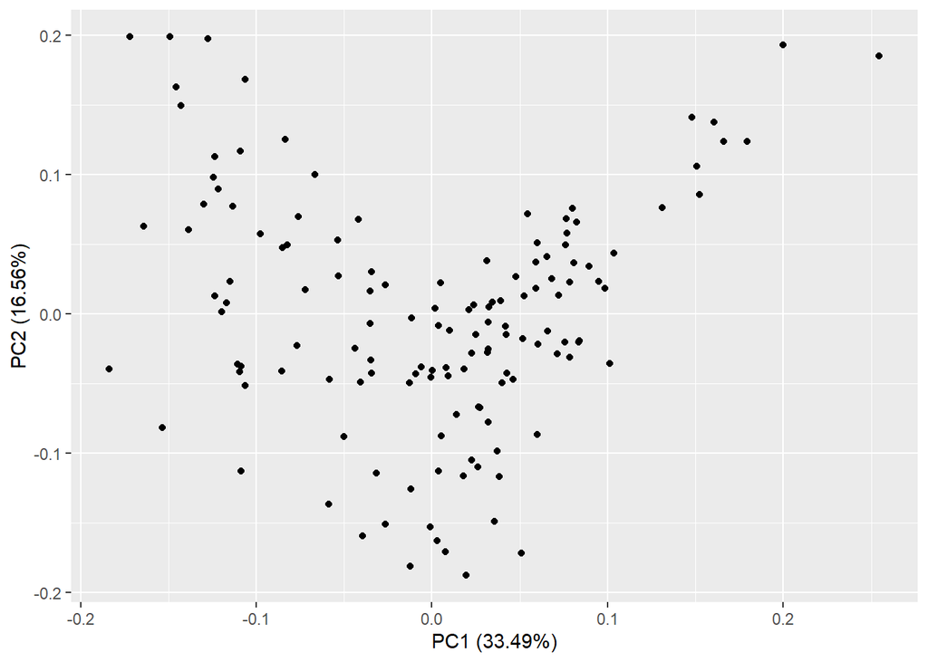

```r
autoplot(channel.pca)
```

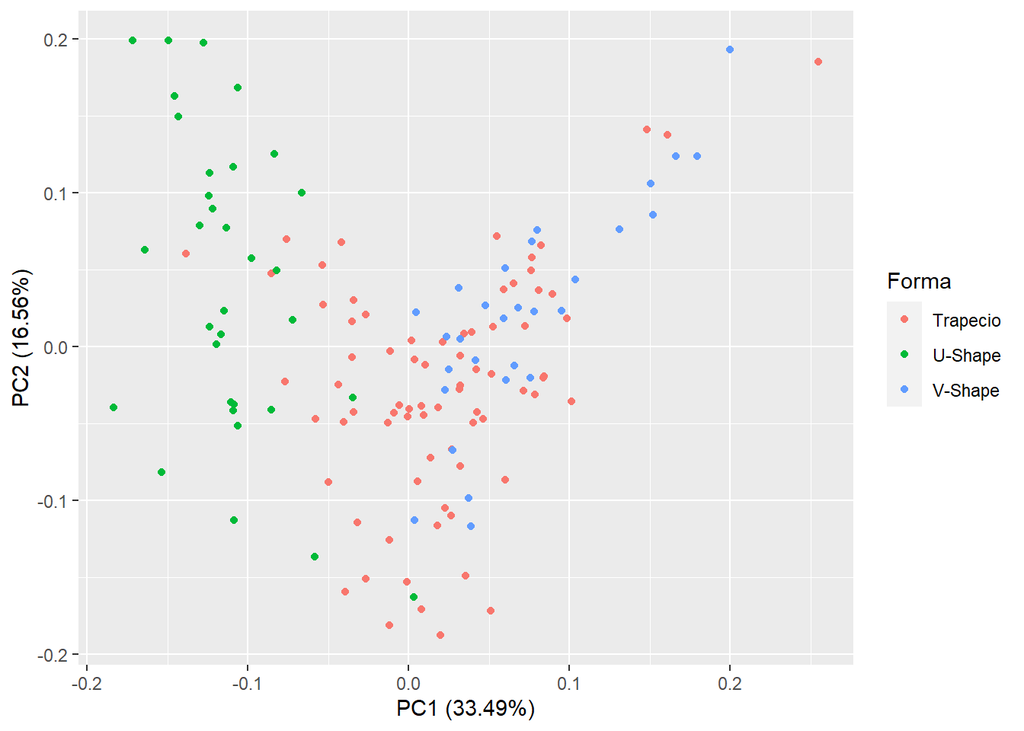

```r
autoplot(channel.pca, data = channel, colour = 'Forma')
```

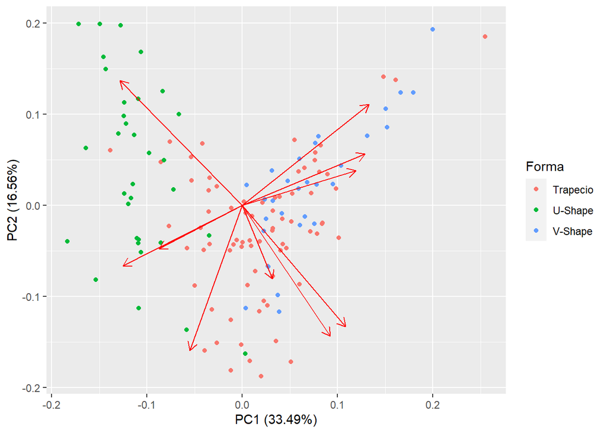

```r
autoplot(channel.pca, data = channel, colour = 'Forma', loadings = TRUE)
```

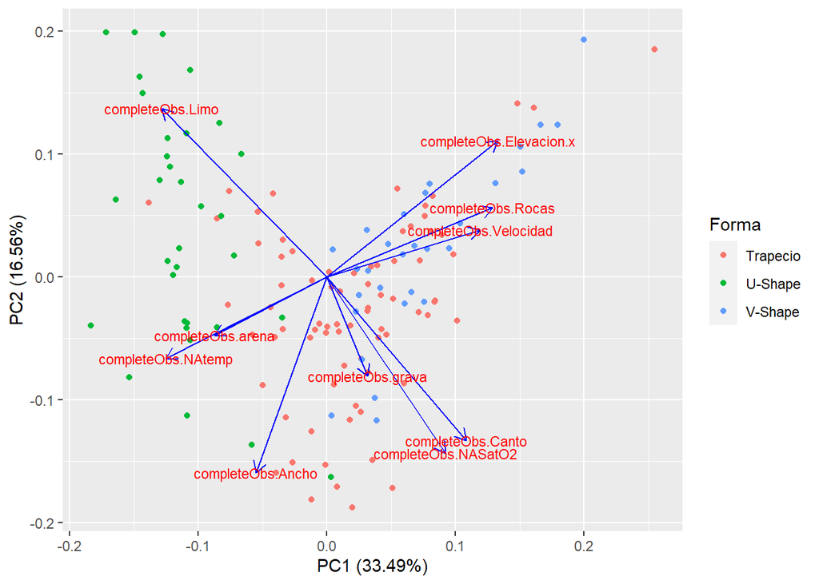

```r
autoplot(channel.pca, data = channel, colour = 'Forma', loadings = TRUE,
         loadings.colour = 'blue',
         loadings.label = TRUE, loadings.label.size = 3)
```

Otra manera de ver el grafico

```r
# ggbiplot(channel.pca, labels=rownames(channel$Forma))
```

3.2 Vamos a ver la contribucion de cada una de las variables.

```r
variance <- (channel.pca$sdev)^2

# Cargar los loadings
loadings <- channel.pca$rotation
round(loadings, 2)[ , 1:3]
```

```
##                           PC1   PC2   PC3
## completeObs.Elevacion.x  0.40  0.33 -0.19
## completeObs.Ancho       -0.16 -0.47 -0.44
## completeObs.Velocidad    0.36  0.11  0.41
## completeObs.Rocas        0.38  0.17 -0.18
## completeObs.Canto        0.32 -0.40 -0.10
## completeObs.grava        0.09 -0.24  0.63
## completeObs.arena       -0.26 -0.14 -0.11
## completeObs.Limo        -0.38  0.41 -0.10
## completeObs.NAtemp      -0.37 -0.20  0.36
## completeObs.NASatO2      0.27 -0.43 -0.12
```

```r
print(channel.pca)
```

```
## Standard deviations (1, .., p=10):
##  [1] 1.82992315 1.28683255 1.18946223 1.07584685 0.89995265 0.76399277
##  [7] 0.70801267 0.62231167 0.37268728 0.04612058
##
## Rotation (n x k) = (10 x 10):
##                                 PC1        PC2         PC3         PC4
## completeObs.Elevacion.x  0.39615124  0.3312904 -0.19490883  0.28422267
## completeObs.Ancho       -0.16405478 -0.4744099 -0.43650902  0.10139348
## completeObs.Velocidad    0.35548809  0.1140191  0.41306910 -0.00700442
## completeObs.Rocas        0.38339344  0.1690205 -0.18090196 -0.08759678
## completeObs.Canto        0.32322298 -0.3960706 -0.09665874 -0.34691126
## completeObs.grava        0.09466745 -0.2403600  0.62978697  0.31374507
## completeObs.arena       -0.26046769 -0.1408860 -0.10693686  0.67881136
## completeObs.Limo        -0.38269942  0.4088553 -0.09718531 -0.30305650
## completeObs.NAtemp      -0.37358516 -0.1972495  0.35775624 -0.32980922
## completeObs.NASatO2      0.27474489 -0.4278434 -0.11521405 -0.14501367
##                                 PC5           PC6          PC7          PC8
## completeObs.Elevacion.x -0.24462464  0.0872553041 -0.184651840  0.130557822
## completeObs.Ancho       -0.29139434  0.2302480810  0.239558001 -0.561635255
## completeObs.Velocidad    0.03227524 -0.4860783571  0.124372396 -0.655162051
## completeObs.Rocas        0.52380817  0.4012932650  0.414132060 -0.077544103
## completeObs.Canto       -0.33332751 -0.3829257400  0.167112732  0.351218850
## completeObs.grava       -0.27257872  0.4743647187 -0.114860543  0.004670724
## completeObs.arena        0.33215022 -0.4081015160  0.009855948  0.087775229
## completeObs.Limo        -0.16583016 -0.0003924146 -0.351986218 -0.268395095
## completeObs.NAtemp       0.31146226  0.0456037467  0.178964077  0.098098723
## completeObs.NASatO2      0.39949081  0.0422275691 -0.724156487 -0.139749138
##                                 PC9          PC10
## completeObs.Elevacion.x  0.70423149 -0.0007661306
## completeObs.Ancho        0.19091217 -0.0024515868
## completeObs.Velocidad    0.08905142  0.0017012657
## completeObs.Rocas       -0.05514873 -0.4099655074
## completeObs.Canto        0.02763742 -0.4462960258
## completeObs.grava       -0.07731897 -0.3459530412
## completeObs.arena        0.06106687 -0.3894687964
## completeObs.Limo         0.01761358 -0.6011239899
## completeObs.NAtemp       0.66634430 -0.0029056115
## completeObs.NASatO2      0.04292839  0.0032717814
```

```r
rownames(loadings) <- colnames(new_channel2)
scores <- channel.pca$x
```

3.3 Ver graficamente lo que explica cada axis.

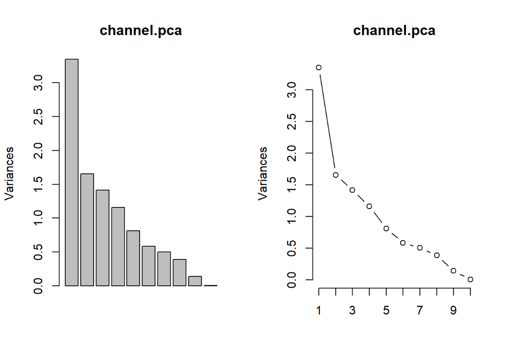

```r
layout(matrix(1:2, ncol=2))
screeplot(channel.pca)
screeplot(channel.pca, type="lines")
```

```
## numeric(0)
```

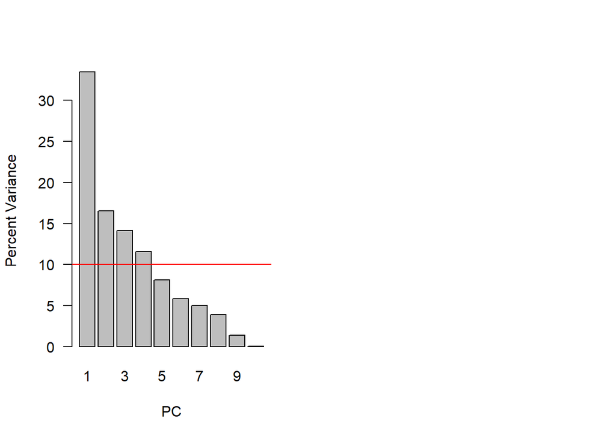

```r
varPercent <- variance/sum(variance) * 100
barplot(varPercent, xlab='PC', ylab='Percent Variance',
names.arg=1:length(varPercent), las=1, col='gray') +
abline(h=1/ncol(new_channel2)*100, col="red")
```

4 Otras formas de visualizar los datos.

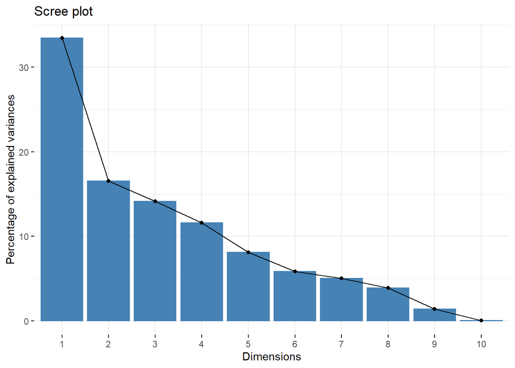

```r
fviz_eig(channel.pca)
```

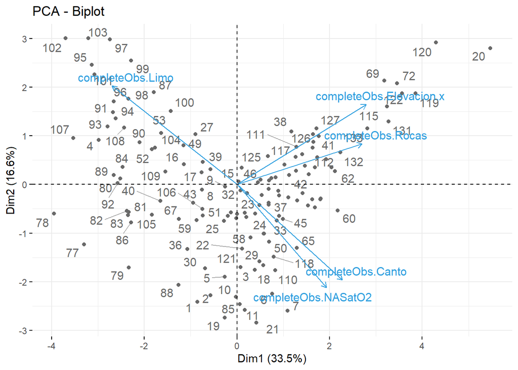

```r
fviz_pca_biplot(channel.pca, repel = TRUE,
                col.var = "#2E9FDF", # Variables color
                col.ind = "#696969",  # Individuals color
                select.var = list(contrib = 5))
```

4.1 Con las elipses.

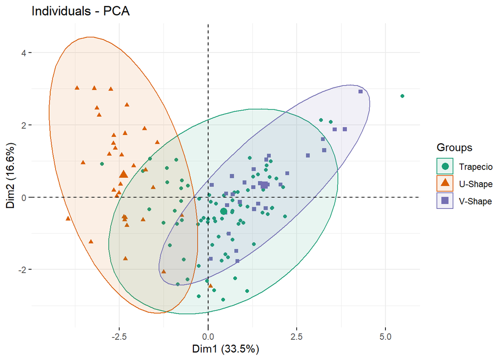

```r
fviz_pca_ind(channel.pca, label="none", habillage=channel$Forma,
     addEllipses=TRUE, ellipse.level=0.95, palette = "Dark2")
```

4.2

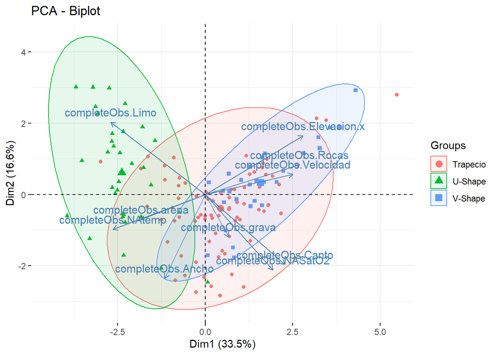

```r
PCA <- fviz_pca_biplot(channel.pca, label = "var", habillage=channel$Forma,
               addEllipses=TRUE, ellipse.level=0.95,
               ggtheme = theme_minimal())

PCA + ggsave("PCA.jpg", width=11, height=8.5)
```

5. Convertirlo en una data.frame para trabajarlo en ggplot2

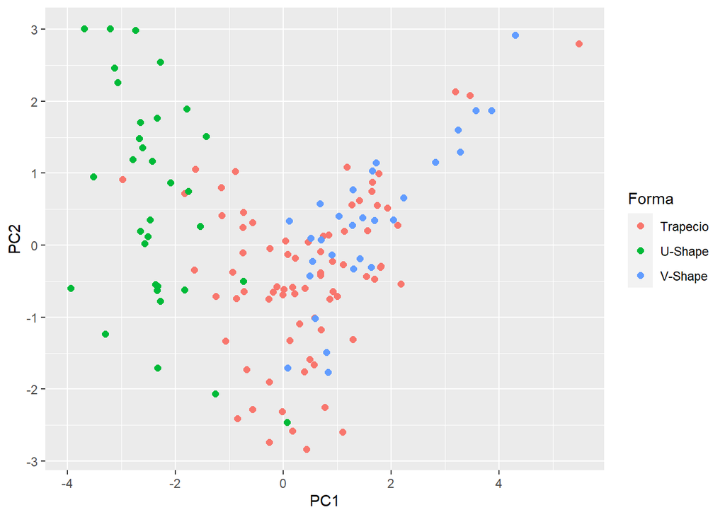

```r
data <- data.table(PC1=channel.pca$x[,1], PC2=channel.pca$x[,2], Forma=  channel[,1])
data <- data[order(channel$Forma),]

ggplot(data, aes(x=PC1,y=PC2)) +
  geom_point(size = 2, aes(color=Forma))
```

6. Otras enlaces de interes.

```r
# http://www.sthda.com/english/articles/31-principal-component-methods-in-r-practical-guide/118-principal-component-analysis-in-r-prcomp-vs-# princomp/
```